# Exploratory Data Analysis of Nucleosome Phasing in reconstituted chromatin

Here we utilize the Phased Nucleosome Array Identification pipeline as used in Baldi et al.,2018 MolCell to characterize nucleosome positioning in in-vitro chromatin assembled with Drosophila Embryonic Extract (DREX) optionally added with late Drosophila extract (TRAX). In vivo MNase-seq of fly embryos from Baldi et al will serve as reference.

```r
library(stringr)
library(rtracklayer)
library(GenomicFeatures)
library(RColorBrewer)
library(matrixStats)
library(grid)
library(gridBase)
library(gridExtra)
library(tsTools)
library(BiocParallel)
library(GenomicAlignments)
library(LSD)
library(csaw)
```

```r
library(pheatmap)
library(Vennerable)
library(writexl)
library(LSD)
library(TxDb.Dmelanogaster.UCSC.dm6.ensGene)
library(IRanges)
#library(ShortRead)
library(ComplexHeatmap)
library(circlize)
library(dendextend)
library(genefilter)
library(tidyverse)
library(zoo)
library(matrixStats)
library(tsTools)
library(Vennerable)
#library(HelpersforChIPSeq)
library(plotly)
library(pbapply)
library(ggsci)
library(BSgenome.Dmelanogaster.UCSC.dm6)
library(multtest)
library(ChIPpeakAnno)
#source("../functions/functions.R")

`%nin%` = Negate(`%in%`)
```

Align raw reads according to Tobias and generate coverages (Run 02_align_slurm.sh -> This should generate .rds coverage objects)

### Load necessary files

Use genome.gtf file corresponding to BDGP6 v104, filtered for genes with only FBgn ID. Load MNase-seq coverages and preprocess data to downsample to lowest library size(important!), size-select nucleosomal fragments, center the fragments and trim to 50 bp (indicative of nucleosomal centers).

```r
my_chromosomes <- c("chr2L","chr2R","chr3L","chr3R","chrX","chrY","chr4")
my_lengths <- seqlengths(keepSeqlevels(TxDb.Dmelanogaster.UCSC.dm6.ensGene, my_chromosomes, pruning.mode = "coarse"))

my_allgenes <- makeTxDbFromGFF("/Users/ra36doj/Desktop/Study/Data/Sequencing/RNAseq/RNASeqAnalysis/genome.gtf",format="gtf")
```

```
## Import genomic features from the file as a GRanges object ... OK
## Prepare the 'metadata' data frame ... OK
## Make the TxDb object ...
```

```
## OK
```

```r
my_allgenes <- genes(my_allgenes)
seqlevelsStyle(my_allgenes) <- "UCSC"
my_allgenes <- keepSeqlevels(my_allgenes,  my_chromosomes, pruning.mode="coarse")
my_allgenes <- my_allgenes[grepl("FBgn",my_allgenes$gene_id)]

### define centers of first 1000bp regions of TSS
my_TSR <- data.frame(chr = seqnames(my_allgenes),
                     center = ifelse(strand(my_allgenes) == "+", start(my_allgenes)+500, end(my_allgenes)-500),
                     strand = strand(my_allgenes))
rownames(my_TSR) <- my_allgenes$gene_id



files <- list.files("../Gizem-DREX/raw/", pattern = ".rds",full.names = T)
file_names <- gsub(".rds","",list.files("../Gizem-DREX/raw/", pattern = ".rds",full.names = F))


rangesList <- lapply(files, function(x) {
   readRDS(x)
})

## apply seqinfo (better done before!)
rangesList <- pblapply(rangesList, function(x) {
  x <- keepSeqlevels(x,my_chromosomes, pruning.mode = "coarse")
  seqlengths(x) <- my_lengths
  x})
### how many reads per chromosome for each sample
lapply(rangesList, function(x) {table(seqnames(x))})
```

```
## [[1]]
##
##    chr2L    chr2R    chr3L    chr3R     chrX     chrY     chr4
## 10314173 11107086 12006758 14647968  5854136     8954   366962
##
## [[2]]
##
##   chr2L   chr2R   chr3L   chr3R    chrX    chrY    chr4
## 7030587 7474427 8134262 9830965 3883772    6639  328732
##
## [[3]]
##
##    chr2L    chr2R    chr3L    chr3R     chrX     chrY     chr4
## 17264723 16510230 18942283 22177460 12249538   131963   945780
##
## [[4]]
##
##    chr2L    chr2R    chr3L    chr3R     chrX     chrY     chr4
## 11019706 11639851 12765635 15392203  6296457    10625   465038
##
## [[5]]
##
##    chr2L    chr2R    chr3L    chr3R     chrX     chrY     chr4
##  7661316  8069745  8857372 10678246  4322993     7562   348402
##
## [[6]]
##
##   chr2L   chr2R   chr3L   chr3R    chrX    chrY    chr4
## 6449098 7026986 7495374 9213684 3782297    8415  228902
```

```r
## filter fragments for size 120-200
rangesList <- pblapply(rangesList, function(x) {
  flt <- width(x) >= 120 & width(x) <= 200
  x[flt]
})

## subsample to smalles library size
minLibSize <- min(unlist(lapply(rangesList, length)))
subRangesList <- pblapply(rangesList, function(x) {
  set.seed(1234)
  idx <- sample(1:length(x), minLibSize)
  x[idx]
})

## coverages of 50bp dyads
dyadCovList <- pblapply(subRangesList, function(x){
  dyads <- resize(x, 50, fix="center")
  coverage(dyads)
})

names(dyadCovList) <- file_names
lapply(file_names, function(x) {
   saveRDS(dyadCovList[[x]], paste0(x,"_dyadCov.rds"))
})
```

## Get autocorrelation function based on Baldi et al

For first step, we look at autocorrelation genome wide (for Chr2 and 3) and calculate repeat lengths which are necessary for Spectral Density Estimation. This reflects the periodicity of nucleosome positions in the data

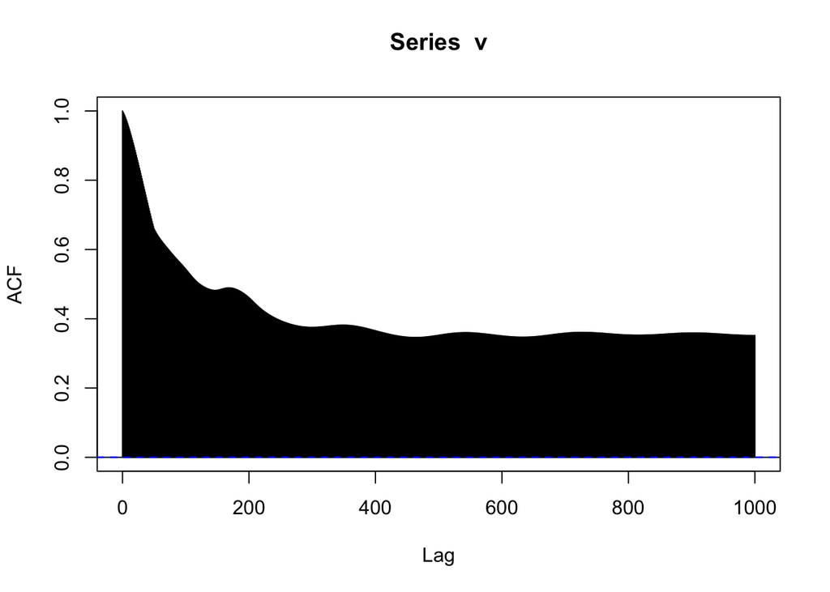

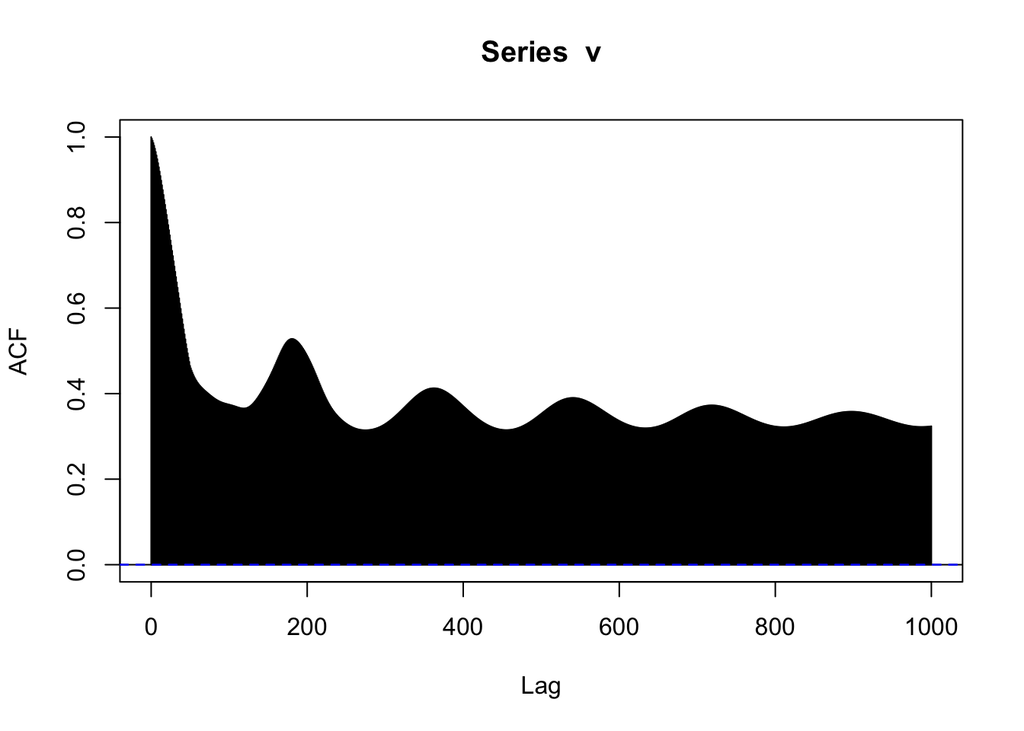

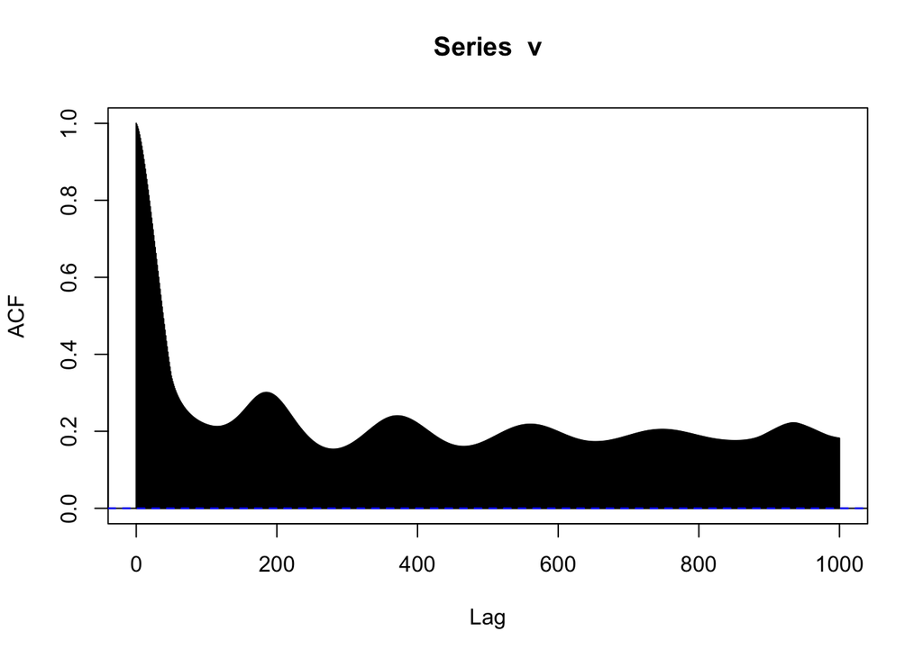

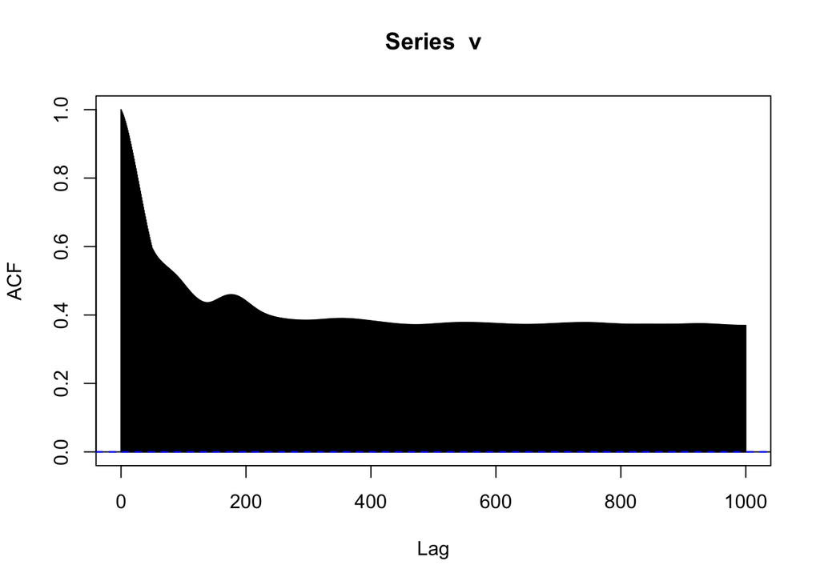

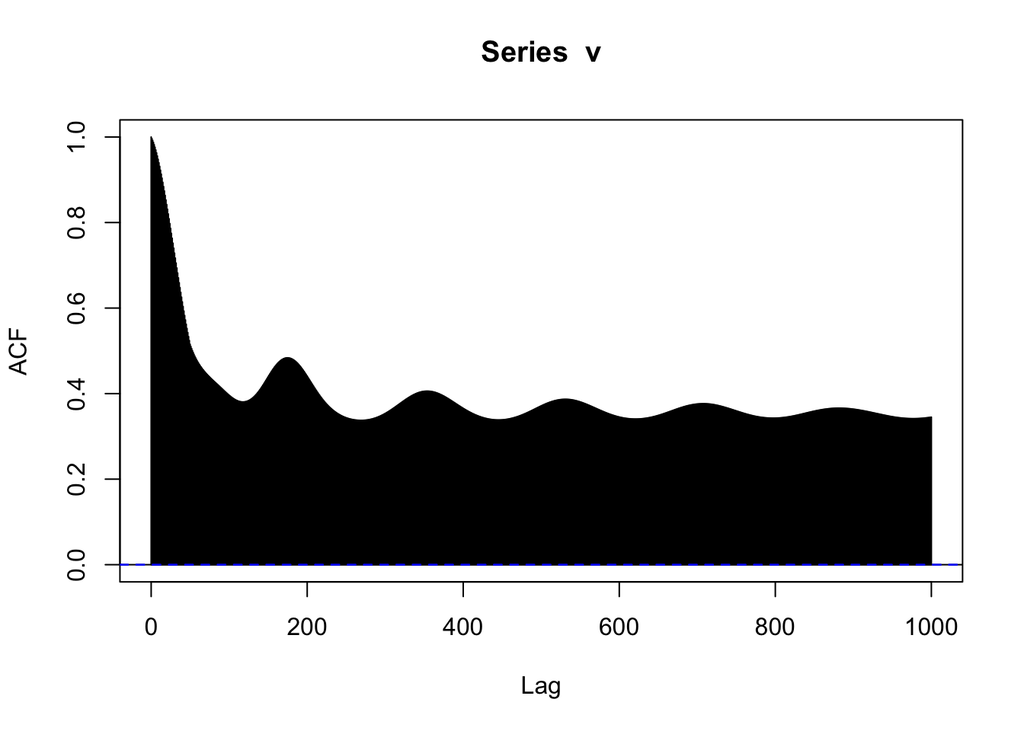

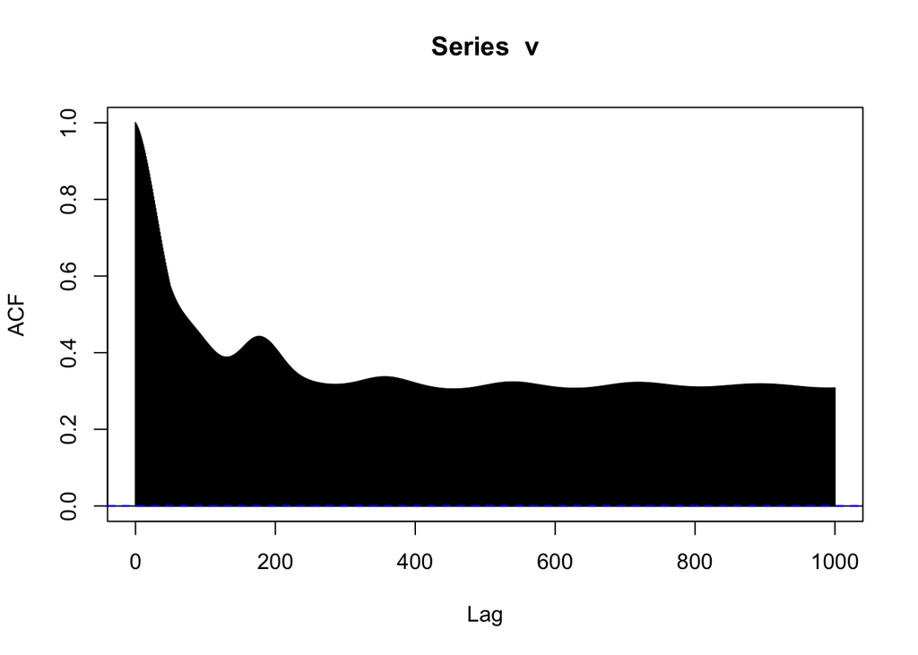

```r
peaks<-function(series,span=100)
{
    z <- embed(series, span)
    s <- span%/%2
    v<- max.col(z) == 1 + s
    result <- c(rep(FALSE,s),v)
    result <- result[1:(length(result)-s)]
    result
}

max.lag <- 1000


repeatLengths <- pblapply(dyadCovList, function(my_cov){
  cov <- my_cov
  v <- as.vector(unlist(cov[c("chr2L","chr2R","chr3L","chr3R")]))
  ac <- acf(v, lag.max=max.lag)

  y <- as.vector(ac$acf)
  x <- 0:max.lag
  peaksPos <- which(peaks(y, span=100))[1:4]
  Peaks <- 1:length(peaksPos)
  fit <- lm(peaksPos ~ Peaks - 1)
  return(list(y,unname(round(fit$coefficients[1]))))

})
```

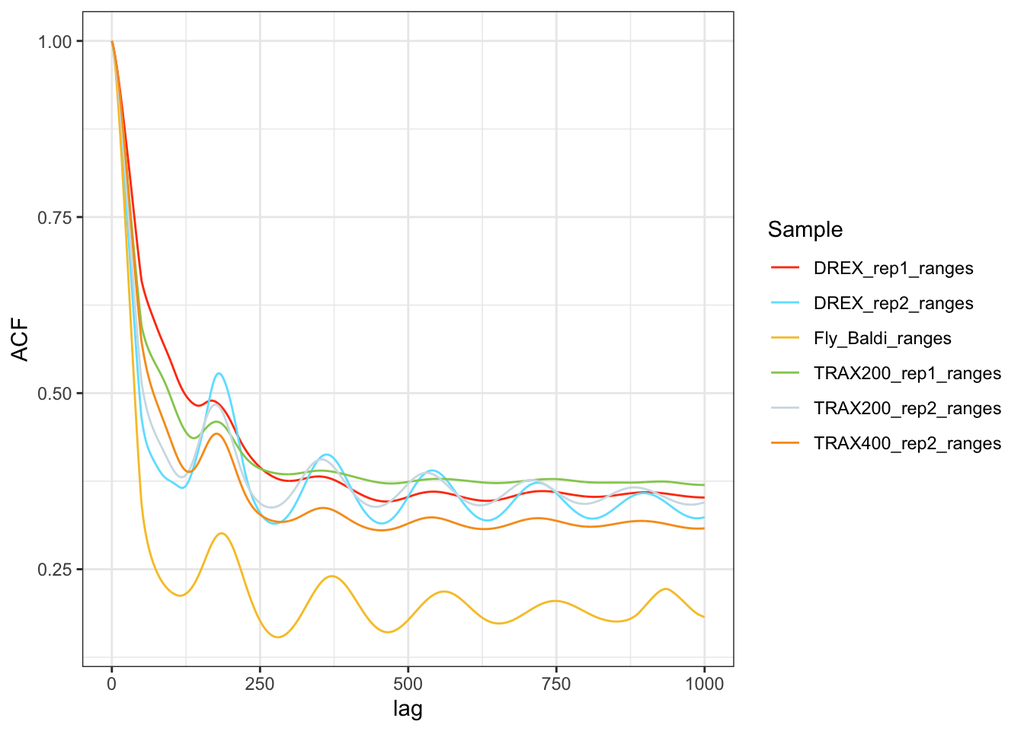

```r
#print(repeatLengths)


plt <- cbind(data.frame(lag=0:max.lag),as.data.frame(lapply(repeatLengths, `[[`, 1))) %>% pivot_longer(cols=-lag,names_to="Sample",values_to = "ACF")        %>% ggplot(aes(x=lag,y=ACF,col=Sample)) + geom_line() + scale_color_tron() +theme_bw()
plt
```

```r
#pdf(file="ACF_genomewide.pdf")
#plt
#dev.off()

spectralRepeatLength <- median(unlist(lapply(repeatLengths, `[[`, 2)))
spectralRepeatLength
```

```
## [1] 180.5
```

```r
saveRDS(spectralRepeatLength, "spectralRepeatLength.rds")
```

In-vivo MNase looks very nice ! - Whole genome repeat length of ~180 bp. DREX and TRAX are variable (batch effect) - nucleosomes might be regularly spaced but they are probably not PHASED. How about if we look first 1000 bp of TSS of genes instead of genome-wide autocorrelation?

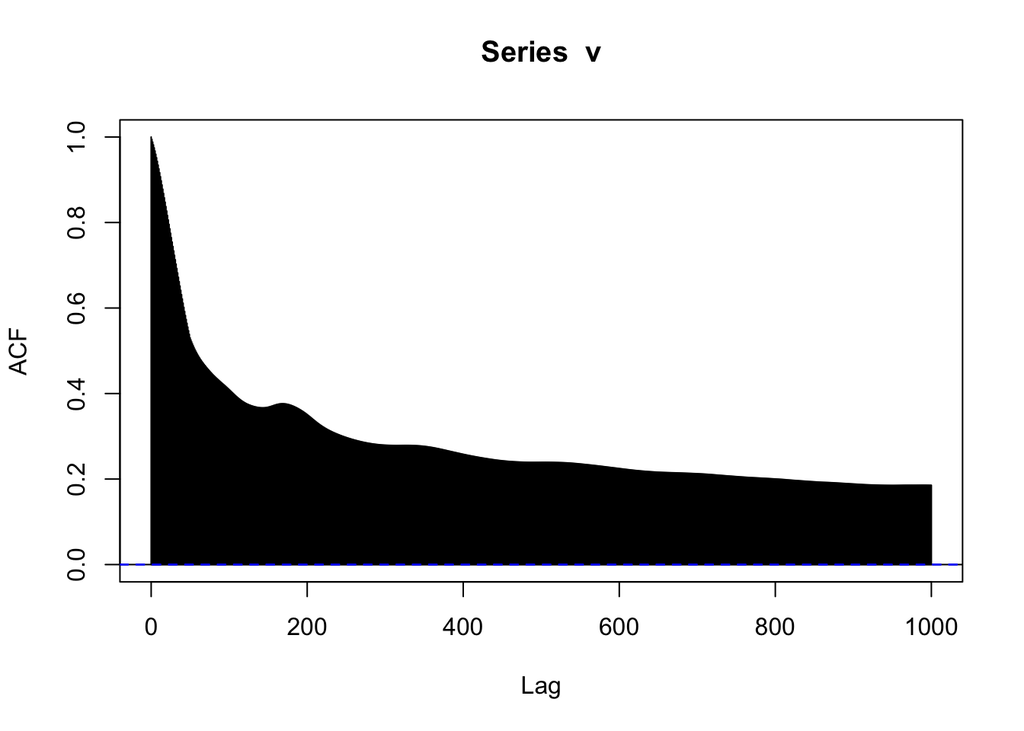

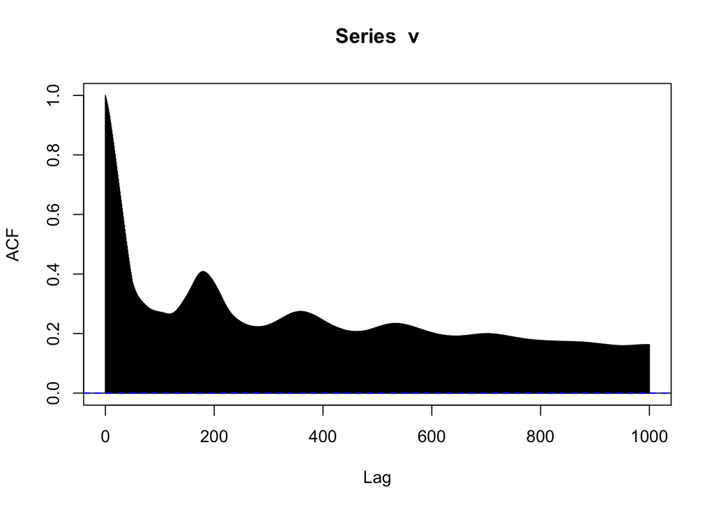

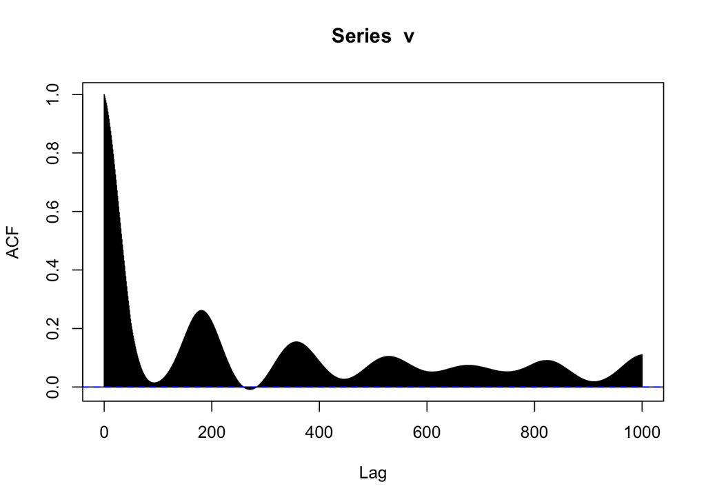

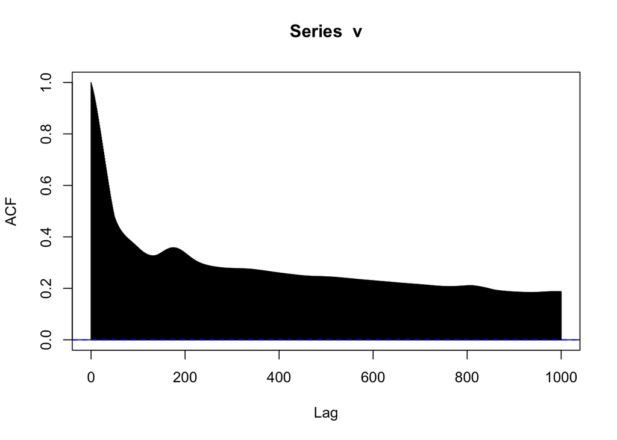

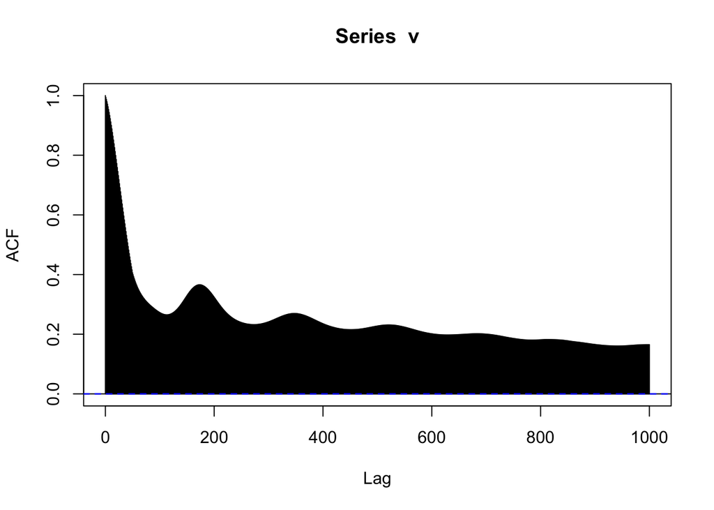

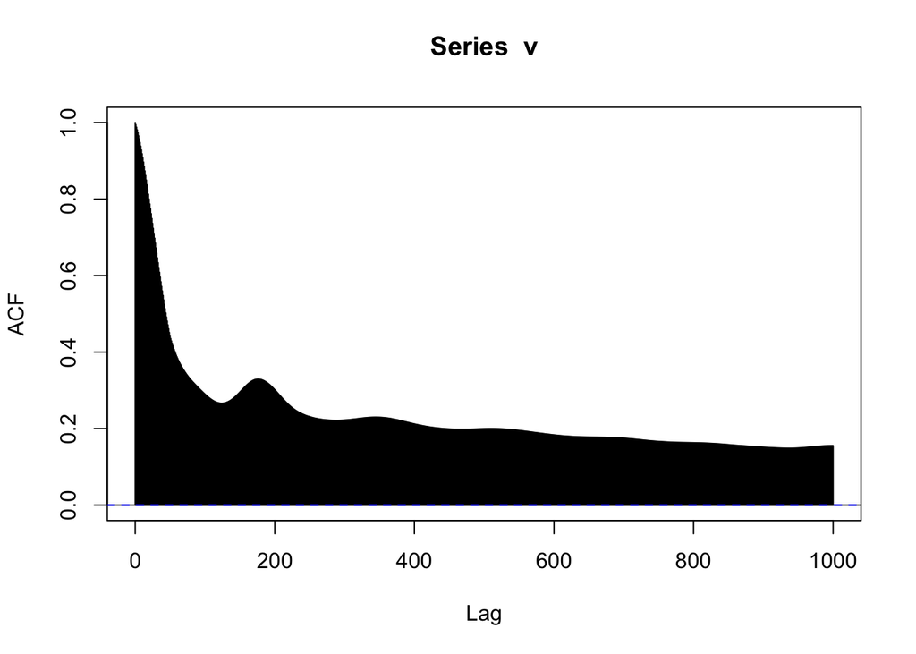

```r
max.lag <- 1000


my_window_size <- 1000

i=1

my_cov <- dyadCovList[[1]]

repeatLengths_TSR <- pblapply(dyadCovList,FUN = function(my_cov){

  ## generate matrices containing 1000 bp windows from start site
  my_mat <- coverageWindowsCenteredStranded(centers = my_TSR,
                                            window.size = my_window_size,
                                            coverage = my_cov)
  ## force to linear for ACF analysis
  v <- as.vector(unlist(t(my_mat)))
  ac <- acf(v,lag.max = max.lag)
  y <- as.vector(ac$acf)
  x <- 0:max.lag
  peaksPos <- which(peaks(y, span=100))[1:4]
  Peaks <- 1:length(peaksPos)
  if (all(is.na(peaksPos))){
    return(list(y,NA))
  } else {
    fit <- lm(peaksPos ~ Peaks - 1)
    return(list(y,unname(round(fit$coefficients[1]))))
  }

})
```

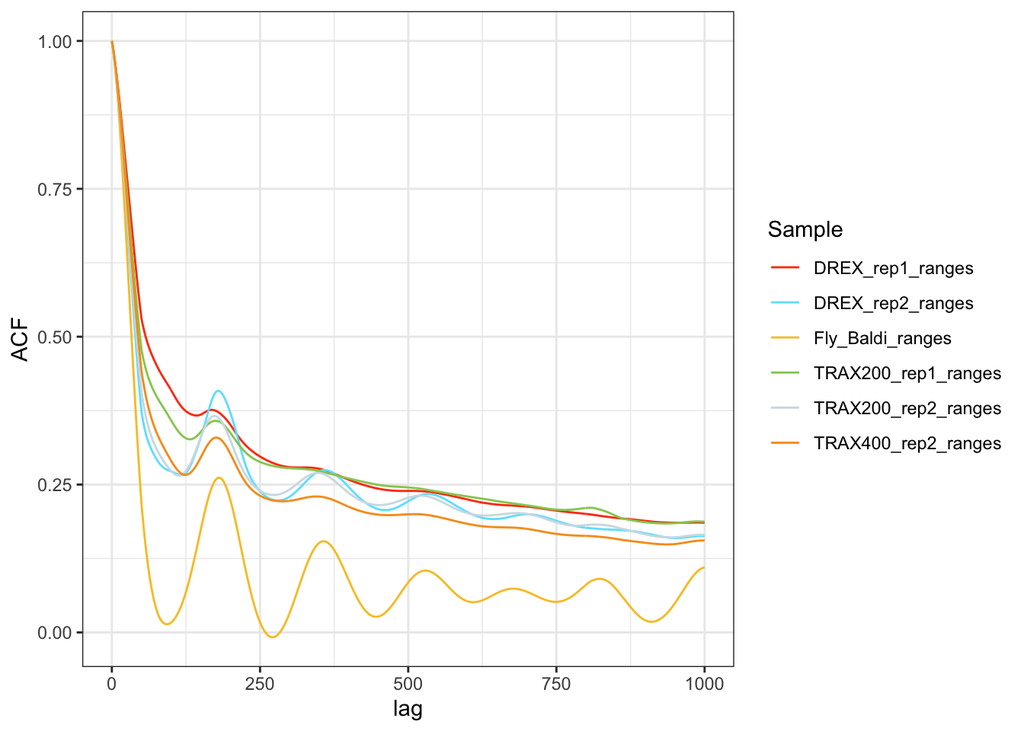

```r
#print(repeatLengths_TSR)


plt <- cbind(data.frame(lag=0:max.lag),as.data.frame(lapply(repeatLengths_TSR, `[[`, 1))) %>% pivot_longer(cols=-lag,names_to="Sample",values_to = "ACF")        %>% ggplot(aes(x=lag,y=ACF,col=Sample,group=Sample)) + geom_line() + scale_color_tron() +theme_bw()
plt
```

```r
#pdf(file="ACF_TSR.pdf")
#plt
#dev.off()

spectralRepeatLength_TSR <- median(unlist(lapply(repeatLengths_TSR, `[[`, 2)),na.rm = T)
spectralRepeatLength_TSR
```

```
## [1] 174
```

```r
saveRDS(spectralRepeatLength_TSR, "spectralRepeatLength_TSR.rds")
```

Similar patterns observed for the first 1000 bp of genes.

Dyad coveraages were used to calculate SDEs using 04_SDE. scripts. In short, Spectral Density Estimation searches for periodicity of a given value (here ~180bp) in series-like data. Arrays of high regularity are identified by a high SDE score and are called as Phased Nucleosome Arrays (PNAs). The generated arrays were z-score transformed (per chromosome z-score transformation) and visualized on IGV. Identify PNAs at two cutoffs (z=2.5 and z=1.5)

Identify PNAs that are statistically significant from across samples. First we ‘call’ PNAs using an arbitrary threshold (only the high-value threshold was used for downstream analyses).

```r
my_samples <- list.files(pattern="_dyadCov_spec_180.5.rds")

specsList <- lapply(my_samples, function(x) {
   readRDS(x)
})

## standardize, return linear
stdSpecsList <- pblapply(specsList, function(covs) {
    v <- log2(as.vector(unlist(covs)))
    flt <- v!=0 & !is.infinite(v)
    m <- mean(v[flt], na.rm=T)
    std <- sd(v[flt], na.rm=T)
    covss <- round(2^(((log2(covs)-m) / std)), 2)
    names(covss) <- names(covs)
    covss
})

names(stdSpecsList) <- my_samples
## get the condition mean  - leave out replicate 1

FlyWT <- grepl("Fly_Baldi", my_samples)
DREX <- grepl("DREX_rep2", my_samples)
TRAX <- grepl("TRAX200_rep2", my_samples)

#aeraging when multiple replicates
specAvgWT <- Reduce("+", stdSpecsList[FlyWT])/sum(FlyWT)
specAvgDREX <- Reduce("+", stdSpecsList[DREX])/sum(DREX)
specAvgTRAX <- Reduce("+", stdSpecsList[TRAX])/sum(TRAX)

cutoff_high <- 2.5
cutoff_low <- 1.5

## get PNAs on which differences should be estimated
wtPNA_high <- as(IRanges::slice(specAvgWT, lower=cutoff_high, rangesOnly=T), "GRanges")
DREXPNA_high <- as(IRanges::slice(specAvgDREX, lower=cutoff_high, rangesOnly=T), "GRanges")
TRAXPNA_high <- as(IRanges::slice(specAvgTRAX, lower=cutoff_high, rangesOnly=T), "GRanges")

### similar number of PNAs for all conditions !

olPNA_high <- GenomicRanges::reduce(c(wtPNA_high,DREXPNA_high,TRAXPNA_high))
# filter regions > 500 bp
olPNA_high <- olPNA_high[width(olPNA_high)>500]
olPNA_high
```

```
## GRanges object with 11857 ranges and 0 metadata columns:
##           seqnames          ranges strand
##              <Rle>       <IRanges>  <Rle>
##       [1]    chr2L     13312-15811      *
##       [2]    chr2L     21712-22511      *
##       [3]    chr2L     31112-31911      *
##       [4]    chr2L     32312-33511      *
##       [5]    chr2L     44612-46211      *
##       ...      ...             ...    ...
##   [11853]     chr4 1124112-1125111      *
##   [11854]     chr4 1129012-1129611      *
##   [11855]     chr4 1180612-1181711      *
##   [11856]     chr4 1228412-1229211      *
##   [11857]     chr4 1241112-1241811      *
##   -------
##   seqinfo: 7 sequences from an unspecified genome; no seqlengths
```

```r
### around 11k PNAs

stdSpecsList_sub <- stdSpecsList

## get specs in all samples for all PNAs - keep the exluded Replicates as well
res <- pblapply(stdSpecsList, function(x) {unlist(lapply(x[olPNA_high], mean))})
mat <- Reduce(cbind, res)
colnames(mat) <- gsub("_ranges_dyadCov_spec_180.5.rds","",my_samples)
rownames(mat) <- paste(seqnames(olPNA_high), start(olPNA_high), end(olPNA_high), sep="_")

head(mat)
```

```
##                   DREX_rep1 DREX_rep2 Fly_Baldi TRAX200_rep1 TRAX200_rep2
## chr2L_13312_15811  1.829600  3.133200   1.14400     1.515200     2.745200
## chr2L_21712_22511  2.702500  1.361250   2.32375     4.867500     2.753750
## chr2L_31112_31911  2.292500  2.756250   1.81500     2.407500     2.438750
## chr2L_32312_33511  2.743333  3.217500   0.92000     2.653333     3.604167
## chr2L_44612_46211  2.190000  2.016875   3.27125     2.289375     1.750625
## chr2L_52512_53311  3.063750  2.597500   1.71625     3.518750     2.948750
##                   TRAX400_rep2
## chr2L_13312_15811     1.554800
## chr2L_21712_22511     2.633750
## chr2L_31112_31911     1.688750
## chr2L_32312_33511     2.505000
## chr2L_44612_46211     1.273125
## chr2L_52512_53311     1.875000
```

These ~11k high-threshold PNAs are now stored in matrices (with rownames indicating their genomic position).

We now have MAT object for plotting heatmaps as well as doing differential testing. Here we test this for DREX vs TRAX groups. Take this with a grain of salt as we have only 2 replicates, most PNAs would be classified as false-negatives !

```r
### Here, groups define 2 groups for t.test. In original exmaple, multiple replicates of acf were tested against WT
### We can try testing 2 replicates of TRAX against 2 of DREX
mat_sub <- mat[,grep("DREX|TRAX200",colnames(mat))]

## define groups for testing
groups <- factor(as.integer(grepl("TRAX",colnames(mat_sub))))

mat_sub <- log2(mat_sub+0.01)
p.val <- apply(mat_sub, 1, function(x){t.test(x~groups)$p.value})
logFC <- apply(mat_sub, 1, function(x){t.test(x~groups) -> tt; tt$estimate[2]-tt$estimate[1]})
mt <- mt.rawp2adjp(p.val, "BH")
adj.p.val <- mt$adjp[order(mt$index),2]

df <- data.frame(mat_sub, p.val, adj.p.val, logFC)

head(df,n=10)
```

```
##                   DREX_rep1 DREX_rep2 TRAX200_rep1 TRAX200_rep2      p.val
## chr2L_13312_15811 0.8793921 1.6522341    0.6089984    1.4621570 0.72816160
## chr2L_21712_22511 1.4396231 0.4554916    2.2861419    1.4666271 0.28780288
## chr2L_31112_31911 1.2032012 1.4679315    1.2735159    1.2920455 0.75845739
## chr2L_32312_33511 1.4611793 1.6904171    1.4132330    1.8536630 0.84399151
## chr2L_44612_46211 1.1375035 1.0192571    1.2012418    0.8160877 0.78056471
## chr2L_52512_53311 1.6199998 1.3826673    1.8191572    1.5649878 0.38754248
## chr2L_55412_56211 1.5915597 1.7382274    1.3792051    0.8806855 0.25805969
## chr2L_58712_59411 0.7274537 1.1252732    1.4594316    1.1014580 0.31799517
## chr2L_60212_61211 1.4797479 1.6672109    0.5420104    0.7874325 0.03226305
## chr2L_72012_74011 1.2094534 1.4843960    0.6780719    1.2992447 0.44182767
##                   adj.p.val       logFC
## chr2L_13312_15811 0.9997843 -0.23023535
## chr2L_21712_22511 0.9997843  0.92882712
## chr2L_31112_31911 0.9997843 -0.05278566
## chr2L_32312_33511 0.9997843  0.05764983
## chr2L_44612_46211 0.9997843 -0.06971561
## chr2L_52512_53311 0.9997843  0.19073897
## chr2L_55412_56211 0.9997843 -0.53494828
## chr2L_58712_59411 0.9997843  0.35408132
## chr2L_60212_61211 0.9997843 -0.90875801
## chr2L_72012_74011 0.9997843 -0.35826638
```

```r
#### Nothing is significant ! -- too much variability or actually no diff?

#flt <- df$adj.p.val<0.20 & df$logFC<0
#olPNA[flt]
# downPNA <- olPNA[flt]
```

## Visualization

Plot SDE scores as heatmap; plot locations as Venn Diagrams and see overlap with known Chromatin States (from Kharchenko et al 2012).

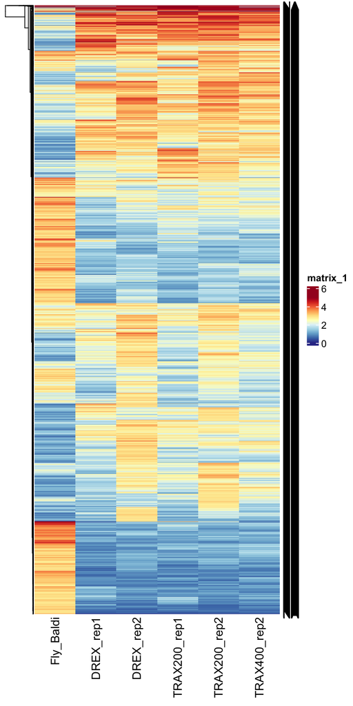

```r
col_fun_unscaled <- colorRamp2(seq(0,5,length=11),rev(brewer.pal(n = 11, name ="RdYlBu")))

hm_pna <- Heatmap(mat[,c(3,1,2,4,5,6)],cluster_columns=F,row_labels = rep(NA,nrow(mat)),col = col_fun_unscaled)

# pdf("Heatmap_PNA.pdf",height=15,width=7)
# hm_pna
# dev.off()
hm_pna
```

```r
roworder_HM <- row_order(hm_pna)
## reorder mat
mat_reordered<- mat[roworder_HM,c(3,1,2,4,5,6)]
```

We can observe that Phased Nucleosome arrays in vivo are quite different from phased nucleosomes in vitro. There is quite some overlap between DREX +/- TRAX samples but also quite some variability can be observed between replicates.

```r
#pdf("Venn_allPNAs.pdf")

ol <-  ChIPpeakAnno::findOverlapsOfPeaks(wtPNA_high,DREXPNA_high,TRAXPNA_high,minoverlap = 150)
```

```
## duplicated or NA names found.
##                 Rename all the names by numbers.
## duplicated or NA names found.
##                 Rename all the names by numbers.
## duplicated or NA names found.
##                 Rename all the names by numbers.
```

```r
ChIPpeakAnno::makeVennDiagram(ol,NameOfPeaks = c("Fly","DREX","TRAX"))
```

[output not shown]

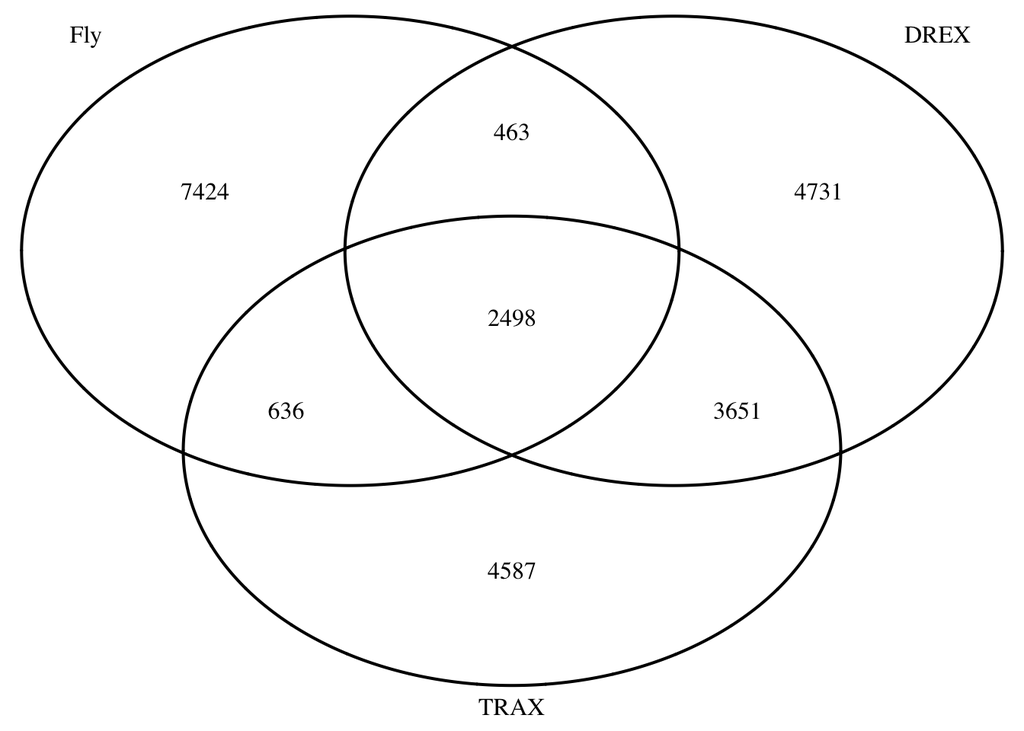

```
## $p.value
##      Fly DREX TRAX pval
## [1,]   0    1    1    0
## [2,]   1    0    1    0
## [3,]   1    1    0    0
##
## $vennCounts
##      Fly DREX TRAX Counts count.wtPNA_high count.DREXPNA_high
## [1,]   0    0    0      0                0                  0
## [2,]   0    0    1   4587                0                  0
## [3,]   0    1    0   4731                0               4731
## [4,]   0    1    1   3651                0               3765
## [5,]   1    0    0   7424             7424                  0
## [6,]   1    0    1    636              644                  0
## [7,]   1    1    0    463              467                472
## [8,]   1    1    1   2498             2605               2645
##      count.TRAXPNA_high
## [1,]                  0
## [2,]               4587
## [3,]                  0
## [4,]               3790
## [5,]                  0
## [6,]                653
## [7,]                  0
## [8,]               2686
## attr(,"class")
## [1] "VennCounts"
```

```r
#dev.off()
```

We can observe variable overlaps between the number of PNAs across conditions.

Now look at chromatin state distribution of shared and distinct PNAs.

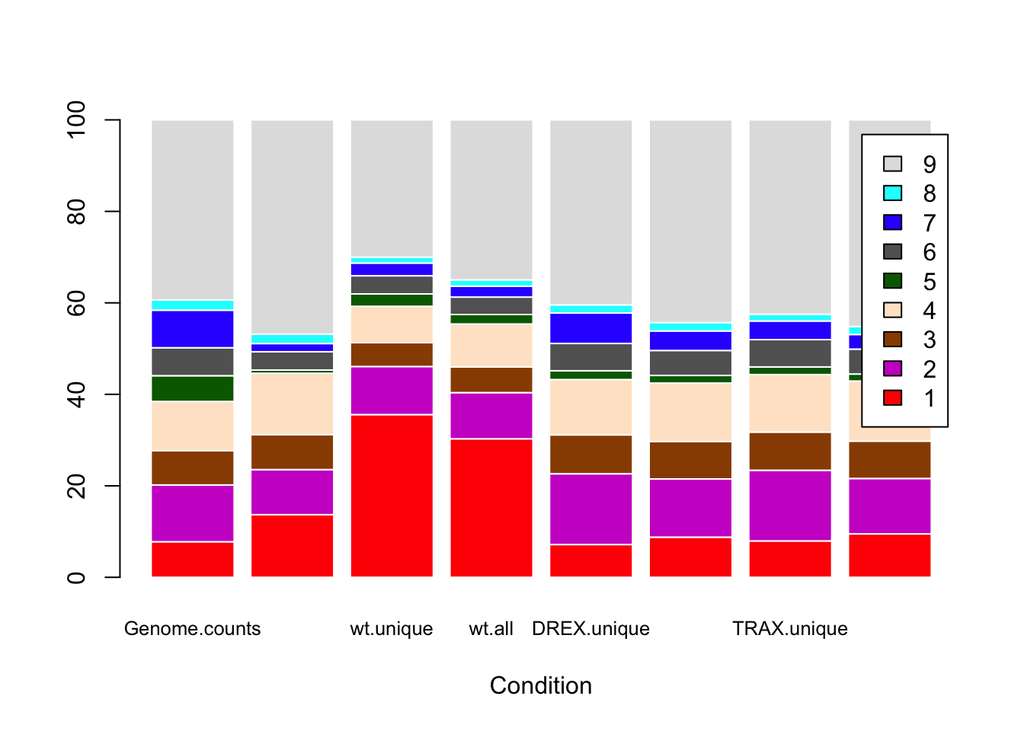

```r
uniquePeaks <- ol$uniquePeaks

my_conds <- c("wt","DREX","TRAX")

chrom_state <- read.delim("9STATE_S2_NArepl_dm6.bed",header=F,col.names = c("seqnames","start","end","strand","state")) %>%  makeGRangesFromDataFrame( keep.extra.columns = T)

# Note: This takes a while to run, so load the table directly
# ### initialize dataframe for barplots
#
# counts_table <- as.data.frame(chrom_state) %>% group_by(state) %>% summarize(Genome.counts=sum(width))
#
# ### first common peaks in all 3 datasets
#
# common_peaks <- findOverlaps(ol$peaklist$`wtPNA_high///DREXPNA_high///TRAXPNA_high`,chrom_state,ignore.strand=T)
#
# counts_table[,"CommonAll"] <- table(chrom_state[as.data.frame(common_peaks)$subjectHits]$state) %>% data.frame() %>% select("Freq")
#
# i <-3
#
# for (i in my_conds){
#   my_cond <- my_conds[i]
#   my_cond_unique <- uniquePeaks[grepl(my_cond,names(uniquePeaks))]
#   my_cond_all <- ol$all.peaks[grep(my_cond,names(ol$all.peaks))][[1]]
#
#   int_unique <- findOverlaps(my_cond_unique,chrom_state,ignore.strand=T)
#   int_all <- findOverlaps(my_cond_all,chrom_state,ignore.strand=T)
#
#   counts_table[,paste0(my_cond,".unique")] <- table(chrom_state[as.data.frame(int_unique)$subjectHits]$state) %>% data.frame() %>% select("Freq")
#   counts_table[,paste0(my_cond,".all")] <- table(chrom_state[as.data.frame(int_all)$subjectHits]$state) %>% data.frame() %>% select("Freq")
# }
#
#
#rownames(counts_table) <- counts_table$state
#
#counts_pct <- apply(counts_table[,c(-1)], 2, function(x){x*100/sum(x,na.rm=T)})
#
#saveRDS(object = counts_pct, file="counts_pct.rds")


counts_pct <- readRDS(file="counts_pct.rds")

#pdf("PNAs_ChromState.pdf",width=10,height=5)
barplot(counts_pct,border="white",xlab="Condition",col=c("#FF0000","#CC00CC","#994C00","#FFE5CC","#006600","#636363","#3333FF","#00FFFF","#E0E0E0"),cex.names=0.8,legend.text = c("1","2","3","4","5","6","7","8","9"))
```

```r
#dev.off()
```

We can see WT unqiue (.ie. fly embryo) PNA are located majorly within chromatin states 1,2 -> which is on active promoters and gene bodies. In contrast, in vitro PNAs are not on promoters, but rather on chromatin states 9 (silent chromatin with no modifications) and 8-6 (facultative and constitutive heterochromatin).

Also possible generate heatmaps of MNase-seq signal around TSS - pick top 10% responsive -> TO DO FOR LATER!

```r
my_TSS <- data.frame(chr = seqnames(my_allgenes),
                     center = ifelse(strand(my_allgenes) == "+", start(my_allgenes), end(my_allgenes)),
                     strand = strand(my_allgenes))
rownames(my_TSS) <- my_allgenes$gene_id

### load resized fragSelected coverages

my_coverage_file_names <- list.files(pattern = ".*dyadCov.rds")

my_covs<-lapply(my_coverage_file_names,function(x){
          readRDS(x)
        })
names(my_covs) <- gsub("_dyadCov.rds","",my_coverage_file_names)

### Generate windows

my_window_size <- 2000
my_binning <- 2


mat_path <- file.path("./matrices_site_centered")

if(!dir.exists(mat_path))
  dir.create(mat_path)

i=1


parallel::mclapply(seq_along(my_covs), mc.cores = 4, FUN = function(i){

    my_name <-  paste("mat.TSS", gsub("_ranges","", names(my_covs[i])), sep=".")

    my_cov <- my_covs[[i]]

    my_mat <- coverageWindowsCenteredStranded(centers = my_TSS,
                                              window.size = my_window_size,
                                              coverage = my_cov)

    my_mat <- binMeansMatrix(my_mat, my_binning)

    assign(my_name, my_mat)
    fname <- file.path(mat_path,my_name)
    save(list = my_name, file = paste0(fname, ".rda", sep=""))

})


my_mat_file_names <- list.files(path = "matrices_site_centered/",pattern = "^mat\\..*rda$")

for(i in seq_along(my_mat_file_names)){

  load(file.path("matrices_site_centered//", my_mat_file_names[i]))

}

my_mats <- ls(pattern = "^mat.TSS")


####################### Differential heatmaps -> Generate heatmaps with log2(CombKD) - log2(GFP) matrices --
##### alternatively do K means on them and use that order on GFP + Comb KD plot
##### do this only for Msl2 -->  msl3 is secondary anywayy. We can later compare this to genebody plots



my_mats_sub <- my_mats[c(3,2,5)]

  # diff_mat_1 <- get(my_mats_site_chip[1])
  # diff_mat_1[diff_mat_1 < 1] <- 1
  #
  # diff_mat_2 <- get(my_mats_site_chip[2])
  # diff_mat_2[diff_mat_2 < 1] <- 1
  #
  diff_mat <- log2(get(my_mats_sub[2])+0.1)-log2(get(my_mats_sub[1])+0.1)    #### difference matrix


  ##ordering by difference
  ##my_order_diff <- order(rowMeans(diff_mat[,180:220]), decreasing = T)
  #orderMats(my_mats = c("diff_mat"),
  #          my_order = my_order_diff)

  # #ordering bz k-means
  # k <- 3
  # km <- kmeans(diff_mat, centers = k)
  # my_order_km <- unlist(sapply(1:k, function(i){which(names(km$cluster) %in% names(km$cluster)[km$cluster == i])}))
  #
  # orderMats(my_mats = c("diff_mat"),
  #           my_order = my_order_km)




  #
  # my_order <- order(rowMeans(get(my_mats_site_chip[grep("GFP",my_mats_site_chip)])), decreasing = T)

  # orderMats(my_mats = my_mats_site_chip,
  #           my_order = my_order_diff)

  orderMats(my_mats = my_mats_site_chip,
            my_order = my_order_km)

  my_order <- order(rowMeans(get(my_mats_sub[1])), decreasing = T)

  orderMats(my_mats = my_mats_sub,my_order=my_order)

  all(sapply(seq_along(my_mats_sub), function(i){(identical(rownames(get(my_mats_sub[length(my_mats_sub)])), rownames(get(my_mats_sub[i]))))}))
  #

  png(paste("heatmaps",".png",sep=""), height = 7, width = 7, units = "in", res = 200)


  HelpersforChIPSeq::plotHeatmap(my_sample_mats = my_mats_sub,
                                    my_sample_names = my_mats_sub,
                                    my_site_name = "my_TSS",
                                    my_binning = my_binning,
                                    my_colors = colorRampPalette((brewer.pal(n = 9, name ="OrRd")))(100),
                                    min_value = 21,
                                    max_value = 24
   )

  dev.off()


  png(paste("heatmaps.Km.",my_site,"_",gsub("\\$","",my_chip),".png",sep=""), height = 7, width = 3.5, units = "in", res = 200)

  HelpersforChIPSeq::plotHeatmap(my_sample_mats = c("diff_mat"),
                                 my_sample_names = paste(c("log2(CombKD)-log2(Control)"),my_site,sep="   "),
                                 my_site_name = my_site,
                                 my_binning = my_binning,
                                 my_colors = colorRampPalette(rev(brewer.pal(n = 9, name ="RdBu")))(100),
                                 min_value = -3,
                                 max_value = 3
  )


  dev.off()
```